# BDCC_Technical_Report

```python
def read_psei(path):
    """" Returns `pandas` DataFrame of PSEi index data from `path`."""
    # Read PSEi data
    df = pd.read_csv(f'{path}/PSEI.PS.csv',
                     parse_dates=['Date'],
                     usecols=['Date', 'Open', 'Close'])
    df = df.dropna()
    df['Previous_Close'] = df['Close'].shift(1)
    df['Close_1day'] = df['Close'].shift(-1)
    df['Close_3day'] = df['Close'].shift(-3)
    df['Close_20day'] = df['Close'].shift(-20)

    df['close_pct'] = df['Close'].pct_change()
    df['close_pct_1day'] = df[
        'Close_1day'] / df['Close'] - 1
    df['close_pct_3day'] = df['Close_3day'] / df['Close'] - 1
    df['close_pct_20day'] = df['Close_20day'] / df['Close'] -1

    df['baseline_pct'] = df['close_pct'].shift(1)
    df['baseline_val'] = df['Previous_Close'] * (1+df['baseline_pct'])

    return df[['Date', 'Close', 'Previous_Close', 'Open',
               'close_pct', 'baseline_pct',  'baseline_val',
               'close_pct_1day', 'close_pct_3day', 'close_pct_20day',
               'Close_1day', 'Close_3day', 'Close_20day']]
```

```python
df_psei = read_psei(path)
```

```python
def read_gdelt(path):
    """" Returns `pandas` DataFrame of GDELT data from `path`."""
    # Read PSEi data
    df = pd.read_csv(f'{path}/gdelt_agg_daily.csv',
                     parse_dates=['DATEADDED'])
    # Create Date Tomorrow
    df['Date_Tomorrow'] = df['DATEADDED'] - datetime.timedelta(days=-1)
    df = df.set_index(['DATEADDED'])

    # Calculate weighted averages
    df['weighted_GS'] = df['weighted_GS'] / df['NumMentions']
    df['weighted_tone'] = df['weighted_tone'] / df['NumMentions']


    return df.reset_index()
```

```python
df_gdelt = read_gdelt(path)
```

Aside from getting the weighted GoldStein and Tone values for every event in the GDELTv2 dataset, rolling averages with user-defined window values *(i.e. 2, 3, 5, 10, 20)* are also obtained and will serve as additional features in the analysis. This is to make the analysis more granular by examining the effect of Goldstein and Average Tone across different windows in the prediction of PSEi.

```python
# Calculate moving arranges for `weighted_GS` and `weighted_tone`
columns  = ['weighted_GS', 'weighted_tone']

for i in columns:
    for j in [2, 3, 5, 10, 20]:
        df_gdelt[f'MA{j}_{i}'] = df_gdelt[i].rolling(window=j).mean()
```

Both the **GDELTv2** and **PSEi** datasets were preprocessed individually in the preceding sections. Now, let us merge these two datasets in preparation for further analysis using `data_prep` function. The combined dataset is shown below in Table 6:

```python
def data_prep(gdelt, psei):
    """Returns merged `pandas` of `dfs`"""

    df = (gdelt.merge(psei, left_on = 'Date_Tomorrow',
    right_on = 'Date',
    how='left')
    .reset_index(drop=True)
    .drop(columns=['Date_Tomorrow']))

    df =  df[df['DATEADDED']>='2016-06-01'].reset_index(drop=True)

    df.drop(['Date'], axis=1, inplace=True)

    df = df.rename(columns={'DATEADDED':'Date'})

    return df.dropna(subset=['Previous_Close','Close']).reset_index(drop=True)
df_model = data_prep(df_gdelt, df_psei)
```

```python
table_num = 6
table('Sample postoprocessed dataset.',
      'Combined dataset of the PSEi and GDELT.')
display_table(df_model.head(5))
```

**Table 6. Sample postoprocessed dataset..**  
Combined dataset of the PSEi and GDELT.

|  | Date | weighted_GS | weighted_tone | NumMentions | MA2_weighted_GS | MA3_weighted_GS | MA5_weighted_GS | MA10_weighted_GS | MA20_weighted_GS | MA2_weighted_tone | MA3_weighted_tone | MA5_weighted_tone | MA10_weighted_tone | MA20_weighted_tone | Close | Previous_Close | Open | close_pct | baseline_pct | baseline_val | close_pct_1day | close_pct_3day | close_pct_20day | Close_1day | Close_3day | Close_20day |
| --- | --- | --- | --- | --- | --- | --- | --- | --- | --- | --- | --- | --- | --- | --- | --- | --- | --- | --- | --- | --- | --- | --- | --- | --- | --- | --- |
| 0 | 2016-06-01 | -1.302663 | -4.283505 | 34436 | -0.638775 | -0.498212 | -0.953826 | -0.375439 | -0.020932 | -3.731953 | -3.579059 | -3.765188 | -3.156887 | -3.002211 | 7464.589844 | 7500.790039 | 7506.779785 | -0.004826 | 0.013401 | 7601.309239 | 0.006649 | 0.032949 | 0.044431 | 7514.220215 | 7710.540039 | 7796.250000 |
| 1 | 2016-06-02 | -0.676340 | -5.389464 | 38990 | -0.989501 | -0.651297 | -0.739916 | -0.510213 | -0.111654 | -4.836484 | -4.284457 | -4.080267 | -3.486264 | -3.178112 | 7514.220215 | 7464.589844 | 7511.709961 | 0.006649 | -0.004826 | 7428.564358 | 0.011179 | 0.027757 | 0.042071 | 7598.220215 | 7722.790039 | 7830.350098 |
| 2 | 2016-06-05 | 0.158413 | -4.282630 | 27682 | -0.144837 | -0.122371 | -0.469223 | -0.545292 | -0.123713 | -3.649730 | -3.571914 | -4.077742 | -3.774029 | -3.223672 | 7598.220215 | 7514.220215 | 7549.870117 | 0.011179 | 0.006649 | 7564.180567 | 0.014782 | -0.008103 | 0.032681 | 7710.540039 | 7536.649902 | 7846.540039 |
| 3 | 2016-06-06 | -0.581217 | -3.561409 | 29607 | -0.211402 | -0.290297 | -0.324934 | -0.639380 | -0.156437 | -3.922020 | -3.620289 | -3.933323 | -3.849256 | -3.232175 | 7710.540039 | 7598.220215 | 7645.350098 | 0.014782 | 0.011179 | 7683.159235 | 0.001589 | -0.026016 | 0.012657 | 7722.790039 | 7509.939941 | 7808.129883 |
| 4 | 2016-06-07 | -0.494799 | -2.982280 | 21900 | -0.538008 | -0.305868 | -0.288626 | -0.514271 | -0.189805 | -3.271845 | -3.608773 | -3.451886 | -3.766076 | -3.156476 | 7722.790039 | 7710.540039 | 7724.259766 | 0.001589 | 0.014782 | 7824.520218 | -0.024103 | -0.021804 | 0.003971 | 7536.649902 | 7554.399902 | 7753.459961 |

4.4 EXPLORATORY DATA ANALYSIS

Before we proceeded with building models, we first needed to gain a better understanding of the PSEi and GDELT. The GDELT began as a hefty dataset, and now we have reduced it to a more manageable size. What does it look like now?

We first wanted to see a scope of all Philippine events: does the GDELT only cover Metro Manila? Found in Figure 2 is a map of all events in the GDELT.

```python
eda = pd.read_csv(f'{path}/gdelt_ph.csv',
                  parse_dates=['DATEADDED'])

eda = eda[eda['DATEADDED']>='2016-06-01']
```

```python
with open('key.txt', 'r') as f:
    key = f.read()
```

```python
# Define a layer to display on a map
layer = pdk.Layer(
    "ScatterplotLayer",
    eda[['ActionGeo_Lat', 'ActionGeo_Long']].dropna().drop_duplicates(),
    get_position=["ActionGeo_Long", "ActionGeo_Lat"],
    auto_highlight=True,
    opacity=0.9,
    get_radius=3_200,
    get_fill_color=[255, 192, 51])

# Set the viewport location
view_state = pdk.ViewState(
    longitude=121.7740, latitude=12.8797, zoom=4, min_zoom=4, max_zoom=4)


# Render
r = pdk.Deck(layers=[layer], initial_view_state=view_state,
             mapbox_key=key)
r.to_html('viz.html')
```

[interactive chart not shown]

**Figure 2. Map of all Philippine events documented in the GDELT, 2016-2019.**  
Geo-coded events from this period are found all over the Philippines.

From Figure 2, we can say that the news covers the whole Philippines as it covers events from Batanes to Tawi-Tawi and even news events on Philippine waters.

We then wanted to ask: what is a general picture of the average tone? To answer this, found in Figure 3 is a graph of the daily average tone.

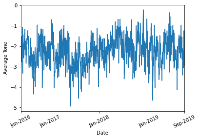

```python
fig, ax = plt.subplots()

eda.groupby('DATEADDED').mean().resample('D').mean()['AvgTone'].plot(ax = ax)

ax.set_xlabel('Date')
ax.set_ylabel('Average Tone')
xfmt = mdates.DateFormatter('%b-%Y')
ax.xaxis.set_major_formatter(xfmt)

axis = ax.get_xticks()

plt.xticks(rotation=25)
plt.minorticks_off()
plt.show();
```

**Figure 3. Daily average tone, 2016-2019.**  
Tone has consistently been below 0, and values on average are at around -2.3419.

Another key figure in the GDELT is the Goldstein score, which gives a theoretical potential impact of the event on the stability of the country. Negative values connote a negative impact, while positive values connote a positive impact. Goldstein scores can range $-10$ to $+10$. Found in Figure 4 is a daily average of the Goldstein score.

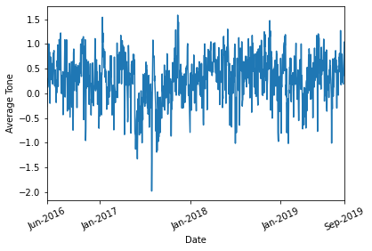

```python
fig, ax = plt.subplots()

eda.groupby('DATEADDED').mean().resample('D').mean()['GoldsteinScale'].plot(ax = ax)

ax.set_xlabel('Date')
ax.set_ylabel('Average Tone')
xfmt = mdates.DateFormatter('%b-%Y')
ax.xaxis.set_major_formatter(xfmt)
plt.xticks(rotation=25)
plt.minorticks_off()
plt.show();
```

**Figure 4. Daily average Goldstein Score, 2016-2019.**  
This ranges from -2 to +1.5.

Finally, we inspected the historical PSEi closing index. Found in Figure 5 is a graph of the PSEi closing prices from 2016 to 2019.

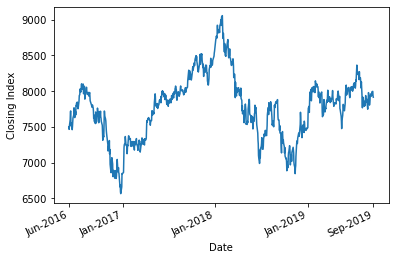

```python
fig, ax = plt.subplots()
eda_psei = df_psei[(df_psei['Date']>='2016-06-01')&
                   (df_psei['Date']<='2019-09-18')].reset_index(drop=True)
eda_psei.plot(x='Date', y='Close', ax = ax)

ax.set_xlabel('Date')
ax.set_ylabel('Closing Index')
ax.get_legend().remove()

xfmt = mdates.DateFormatter('%b-%Y')
ax.xaxis.set_major_formatter(xfmt)
ax.set_xticks(axis)
plt.xticks(rotation=25)
plt.minorticks_off()
plt.show();
```

**Figure 5. Daily PSEi closing index, 2016-2019.**  
The PSEi has experienced erratic changes over the years, even hitting a high of 9,000.

4.5 SUPERVISED LEARNING

With better context of the data in mind, we proceeded with building supervised learning models. Figure 6 shows the steps we took in building the models.

[figure not shown]

**Figure 6. Supervised Learning Implementation.**  
The figure describes the steps undertaken in the supervised learning portion of the project.

4.5.1 DATA SPLIT

```python
# Define train test split
split = 0.70

train = df_model.iloc[:int(len(df_model)*split)]
test = df_model.iloc[int(len(df_model)*split):]
```

4.5.2 FEATURES AND TARGET

The features that we will be using for model training is composed of a combination of data from GDELT and from PSEi. For GDELT, we will be using `weighted_GS` and `weighted_Tone` and their corresponding moving averages which corresponds to average `weighted_GS` and `weighted_Tone` from events 2 days, 5 days, 10 days, and 20 days prior. For PSEi, we will be using `Previous_Close` which corresponds to previous closing index.

The target variable for the models corresponds to the **percent change** from the `Close` price. The percent change (Equation 1) is given by:

$$ Percent(\%) Change = \frac{Close_{t}}{Close} -1 $$

where $Close$ is the current Closing Index for the current trade day and $Close_t$ is the Closing Index for target day $t$.

For this study, we looked into $t = \{-1, 1, 3\}$. These represents Prior Closing Index to predict percent change from prior index to current index, Closing Index a day ahead to predict percent change from current index to next day's index, and Closing Index 3-days ahead to predict percent chagne from current day's index to index 3 days ahead.

```python
# Define features from GDELT
gdelt = ['weighted_GS', 'weighted_tone',
          'MA2_weighted_GS',
          'MA5_weighted_GS',
          'MA10_weighted_GS',
          'MA20_weighted_GS',
          'MA2_weighted_tone',
          'MA5_weighted_tone',
          'MA10_weighted_tone',
          'MA20_weighted_tone',]

# Define features from PSEi
psei = ['Previous_Close']

# Define features
features_set =  psei + gdelt

# Define target variables
target = ['close_pct', 'close_pct_1day', 'close_pct_3day']
```

4.5.3 REGRESSORS USED

There are a total of two regressor models used in this study. We considered these state-of-the-art algorithms as numerous studies already used this to predict stock prices, or market indeces [14] [15] [16] [17] [18] [19].

- **Gradient Boosting Regressor**. We used `sklearn`'s implementation `GradientBoostingRegressor`. GB builds an additive model in a forward stage-wise fashion; it allows for the optimization of arbitrary differentiable loss functions [20] In this study, the loss function used is `ls` or least squares regression.
- **eXtreme Gradiente Boosting Regressor**. We used `xgboost`'s implementation of `XGBRegressor`. XGBoost is an optimized distributed gradient boosting library designed to be highly efficient, flexible and portable [21].

The parameters tuned were `n_estimators`, `max_depth`, and `learning_rate`.

```python
table_num = 7

table('Summary of Parameters Used.',
      'These optimal parameters were obtained using manual gridsearch.')
```

**Table 7. Summary of Parameters Used..**  
These optimal parameters were obtained using manual gridsearch.

| Parameters | Gradient Boosting Regressor | XGBoost |
| --- | --- | --- |
| `n_estimators` | $100$ | $100$ |
| `max_depth` | $3$ | $3$ |
| `learning_rate` | $0.00005$ | $0.05$ |

4.5.4 MODEL EVALUATION

To properly assess the performance of the different models in different prediction horizon, we have defined the baseline and metrics to evaluate. These are further discussed below.

**Baseline**

For all models, the baseline we considered is **Naive Forecasting**. Naive Forecasting is using last period's % change. The predicted `% change` is used to forecast the PSEi index given by: $$ PSEi_{forecast} = PSEi_{prior} * (1 + \% change_{predicted})$$ **MAE and MSE**

To evaluate the model's performance, both Mean Absolute Error (MAE) and Mean-Square Error (MSE) are both considered.

MAE is given by: $$ MAE = \frac{\sum_{i=1}^n |Y_i - \hat{Y_i}|}{n}$$

MSE is given by: $$ MSE = \frac{1}{n} \sum_{i=1}^n (Y_i - \hat{Y_i})^2$$

5 RESULTS AND DISCUSSION

In this section, study results in employing various supervised learning algorithms is discussed. The discussion is divided into three (3) sub-sections:

- **`Intra-day Prediction`**;
- **`1-Day Ahead Prediction`**; *and*
- **`3-Day Ahead Prediction`**.

As a basis for comparison and as a means to evaluate how our prediction model is performing relative to other measures, baseline values are computed using the `Naive Method`. The naive method assumes that the predicted value for the next state is the same value of its previous state. The baseline for predicting percent change in closing prices is done by getting the `MAE` and `MSE` between the test values of percent change in closing prices and the predicted test (proxy) values of percent change in closing prices the day before. Similarly, in computing for the baseline values in predicting PSEi prices, `MAE` and `MSE` scores are still computed. However, this time it is between the test values of PSEi Closing Prices and the predicted test (proxy) values of PSEi Closing Prices such that in obtaining the latter, reflected herein is the computed closing price percent change for the day.

```python
def metrics(true, pred):
    """Returns `mae` and `rmse` of true and pred"""
    return mean_absolute_error(true, pred), mean_squared_error(true, pred)

def calc(test, y):
    """Returns prediction in PSEi value"""
    df = test.copy()
    df['pred'] = y
    df['pred_close'] = df['Previous_Close'] * (1+ df['pred'])
    return df['pred_close']

def ml_model(model, train, test, features, target):
    """Returns fitted model"""
    return model.fit(train[features].values, train[target].values.ravel())

def results(baseline, gbm, xgboost, value='Percent Change'):
    df = pd.DataFrame([baseline, gbm, xgboost])
    df.index = ['Baseline', 'Gradient Boosting', 'XGB']
    df.columns = ['MAE', 'MSE']
    return df

def plot_summary(base, base_test, gbm, gbm_test, xgb, xgb_test):
    df = (pd.DataFrame({'results':{'train':base[0],
                                  'test':base_test[0]},
                        'model':'Baseline'
                      }).append(
          pd.DataFrame({'results':{'train':gbm[0],
                                  'test':gbm_test[0]},
                        'model':'Gradient Boosting Method'
                      })).append(
          pd.DataFrame({'results':{'train':xgb[0],
                                  'test':xgb_test[0]},
                        'model':'XG Boost'
                      }))).reset_index()

    fig, ax = plt.subplots()
    ax = sns.barplot(x="model", y="results", hue="index", data=df,
            hue_order=['train', 'test']);
    ax.legend_.set_title(None)

    ax.set_ylabel('MAE')
    ax.set_xlabel('Algorithm')

    return plt.show();
```

5.1 INTRA-DAY PREDICTION

The goal of the Intra-Day analysis is to provide an approximate prediction of the index and the percent change in the PSEi Closing Price of the **current day** using the features specified in the Supervised Learning section. As discussed earlier, baseline metrics are computed and these are compared to the metrics obtained by our model predictions. These results are summarized in Table 8 and Table 9.

```python
#Baseline
baseline_train = metrics(train['close_pct'], train['baseline_pct'])
baseline_pct = metrics(test['close_pct'], test['baseline_pct'])
baseline_psei = metrics(test['Close'], test['baseline_val'])



#Gradient Boosting
model = ml_model(GradientBoostingRegressor(random_state=42,
                                learning_rate=0.00005,
                                max_depth=3,
                                warm_start=True),
                  train, test, features_set, target[0])

y_intra_train = model.predict(train[features_set].values)
y_intra = model.predict(test[features_set].values)

   # Forecast PSEi index using predicted percent change
pred_intra_train = calc(train, y_intra_train)
pred_intra = calc(test, y_intra)

  # Get MAE and MSE for predicted percent change
gbm_pct_train = metrics(train['close_pct'], y_intra_train)
gbm_pct = metrics(test['close_pct'], y_intra)

  # Get MAE and MSE for forecasted PSEi
gbm_psei_train = metrics(train['Close'], pred_intra_train)
gbm_psei = metrics(test['Close'], pred_intra)



#XG Boost
model = ml_model(xgb.XGBRegressor(objective ='reg:squarederror',
                                  learning_rate = 0.05,
                                  max_depth = 3,
                                  n_estimators = 100),
                  train, test, features_set, target[0])

y_intra_train = model.predict(train[features_set].values)
y_intra = model.predict(test[features_set].values)

  # Forecast PSEi index using predicted percent change
pred_intra_train = calc(train, y_intra_train)
pred_intra = calc(test, y_intra)

  # Get MAE and MSE for predicted percent change
xgboost_pct_train = metrics(train['close_pct'], y_intra_train)
xgboost_pct = metrics(test['close_pct'], y_intra)

  # Get MAE and MSE for forecasted PSEi
xgboost_psei_train = metrics(train['Close'], pred_intra_train)
xgboost_psei = metrics(test['Close'], pred_intra)
```

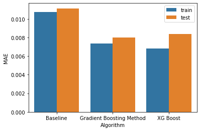

```python
plot_summary(baseline_train, baseline_pct,
             gbm_pct_train, gbm_pct,
             xgboost_pct_train, xgboost_pct)
```

**Figure 7. Intra-Day Prediction Mean Absolute Errors**  
Varying mean absolute error scores between baseline (naive model) and employed regressor models

```python
table_num = 8
table('Summary of Model Performance on Intra-day Prediction',
      'Values are in Percent Change')
display_table(results(baseline_pct, gbm_pct, xgboost_pct))

table('Summary of Model Performance on Intra-day Prediction',
      'Values are in PSEi')
display_table(results(baseline_psei, gbm_psei, xgboost_psei))
```

**Table 8. Summary of Model Performance on Intra-day Prediction.**  
Values are in Percent Change

|  | MAE | MSE |
| --- | --- | --- |
| Baseline | 0.011140 | 0.000207 |
| Gradient Boosting | 0.008031 | 0.000103 |
| XGB | 0.008357 | 0.000115 |

**Table 9. Summary of Model Performance on Intra-day Prediction.**  
Values are in PSEi

|  | MAE | MSE |
| --- | --- | --- |
| Baseline | 85.784068 | 12172.612703 |
| Gradient Boosting | 61.597204 | 6030.312851 |
| XGB | 64.207279 | 6726.724720 |

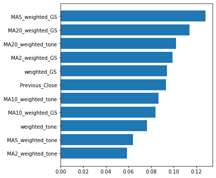

```python
# Plot feature importance from best model
feature_importance = model.feature_importances_
sorted_idx = np.argsort(feature_importance)
pos = np.arange(sorted_idx.shape[0]) + .5
fig = plt.figure(figsize=(12, 6))
plt.subplot(1, 2, 1)
plt.barh(pos, feature_importance[sorted_idx], align='center')
plt.yticks(pos, np.array(features_set)[sorted_idx])
#plt.title('Feature Importance')
plt.show();
```

**Figure 8. Model Feature Importances for Intra-Day Prediction.**  
Ranked features based on importance in the prediction of the target variable.

The top 3 features that stood out for Intra-Day prediction are `MA20_weighted_GS`, `MA5_weighted_GS`, and `MA20_weighted_tone`. This suggests that sentiments from events twenty (20) days and 5 (five) days prior affect the prediction of percent change in Closing Price the most, than the rest of the other features included in the analysis. Specifically, these top features are weighted Goldstein values for both `MA5` (moving average for 5 days) and `MA20` (moving average for 20 days), and weighted Tone values for `MA20`.

5.2 1-DAY AHEAD PREDICTION

Next, **1 (one) day ahead** approximate predictions of the index and the percent change in the PSEi Closing Price are provided. Still using the features specified in the Supervised Learning section, models created seek to beat computed baseline metrics for this specified section. See summarized tables of results in Table 10 and Table 11.

```python
#Baseline
baseline_train = metrics(train['close_pct_1day'], train['baseline_pct'])
baseline_pct = metrics(test['close_pct_1day'], test['baseline_pct'])
baseline_psei = metrics(test['Close_1day'], test['baseline_val'])



#Gradient Boosting
model = ml_model(GradientBoostingRegressor(random_state=42,
                                learning_rate=0.00005,
                                max_depth=3,
                                warm_start=True),
                  train, test, features_set, target[1])

y_1day_train = model.predict(train[features_set].values)
y_1day = model.predict(test[features_set].values)

  # Forecast PSEi index using predicted percent change
pred_1day_train = calc(train, y_1day_train)
pred_1day = calc(test, y_1day)

  # Get MAE and MSE for predicted percent change
gbm_pct_train = metrics(train['close_pct_1day'], y_1day_train)
gbm_pct = metrics(test['close_pct_1day'], y_1day)

  # Get MAE and MSE for forecasted PSEi
gbm_psei_train = metrics(train['Close_1day'], pred_1day_train)
gbm_psei = metrics(test['Close_1day'], pred_1day)



#XG Boost
model2 = ml_model(xgb.XGBRegressor(objective ='reg:squarederror',
                                learning_rate = 0.05,
                                   max_depth = 3,
                                  n_estimators = 100),
                  train, test, features_set, target[0])

y_1day_train = model2.predict(train[features_set].values)
y_1day = model2.predict(test[features_set].values)

  # Forecast PSEi index using predicted percent change
pred_1day_train = calc(train, y_1day_train)
pred_1day = calc(test, y_1day)

  # Get MAE and MSE for predicted percent change
xgboost_pct_train = metrics(train['close_pct_1day'], y_1day_train)
xgboost_pct = metrics(test['close_pct_1day'], y_1day)


  # Get MAE and MSE for forecasted PSEi
xgboost_psei_train = metrics(train['Close_1day'], pred_1day_train)
xgboost_psei = metrics(test['Close_1day'], pred_1day)
```

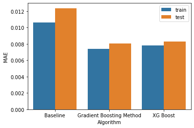

```python
plot_summary(baseline_train, baseline_pct,
             gbm_pct_train, gbm_pct,
             xgboost_pct_train, xgboost_pct)
```

**Figure 9. 1-Day Ahead Prediction Mean Absolute Errors**  
Varying mean absolute error scores between baseline (naive model) and employed regressor models

```python
table('Summary of Model Performance on 1-Day Ahead Prediction',
      'Values are in Percent Change')
display_table(results(baseline_pct, gbm_pct, xgboost_pct))

table('Summary of Model Performance on 1-Day Ahead Prediction',
      'Values are in PSEi')
display_table(results(baseline_psei, gbm_psei, xgboost_psei))
```

**Table 10. Summary of Model Performance on 1-Day Ahead Prediction.**  
Values are in Percent Change

|  | MAE | MSE |
| --- | --- | --- |
| Baseline | 0.012358 | 0.000242 |
| Gradient Boosting | 0.008016 | 0.000103 |
| XGB | 0.008286 | 0.000111 |

**Table 11. Summary of Model Performance on 1-Day Ahead Prediction.**  
Values are in PSEi

|  | MAE | MSE |
| --- | --- | --- |
| Baseline | 112.317222 | 20195.640630 |
| Gradient Boosting | 84.197589 | 11952.119285 |
| XGB | 85.662686 | 12350.567091 |

Similarly,both models have still significantly beaten our baseline (naive model) metric values in terms of obtaining lower `MAE` and `MSE`. For the day-ahead predictions, it is still the Gradient Boosting Regressor which provided the most desirable error scores compared to the XGB regressor. In continuation, the Gradient Boosting Regressor model is still the one that used to identify the features that are relevant and important in predicting our target variable. The feature importance graph is presented below:

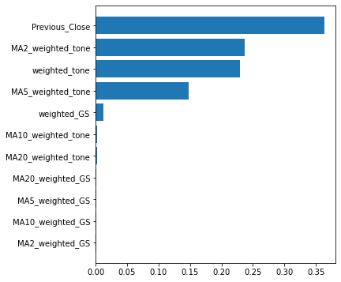

```python
# Plot feature importance from best model
feature_importance = model.feature_importances_
sorted_idx = np.argsort(feature_importance)
pos = np.arange(sorted_idx.shape[0]) + .5
fig = plt.figure(figsize=(12, 6))
plt.subplot(1, 2, 1)
plt.barh(pos, feature_importance[sorted_idx], align='center')
plt.yticks(pos, np.array(features_set)[sorted_idx])
#plt.title('Feature Importance')
plt.show();
```

**Figure 10. Model Feature Importances for 1-Day Ahead Prediction.**  
Ranked features based on importance in the prediction of the target variable.

For the 1-Day ahead predictions, the top 3 features have changed completely compared to the preceding analysis. The three (3) that stood out are the following: '`Previous Close`, `MA2_weighted_tone`, and `weighted_tone`. This tells us that in predicting the percent change in closing price a day ahead, the closing price of the previous day is the most important feature that affects the prediction most. Further, this suggests that sentiments from events two (2) days prior is also one of the top featues. Also, the weighted tone feature appeared 3rd in the ranking. It can also be observed that after 5th spot in the ranking, features appear to be of little to no importance.

5.3 3-DAY AHEAD PREDICTION

Finally, approximate predictions of the index and the percent change in the PSEi Closing Price are provided for the `3-Days Ahead` analysis. The anaylsis used the features specified in the Supervised Learning section. Same as the two previous sets of analyses, regressor models created seek to beat computed baseline metrics for this specific section. Kindly see summarized tables of results in Table 12 and Table 13.

```python
#Baseline
baseline_train = metrics(train['close_pct_3day'], train['baseline_pct'])
baseline_pct = metrics(test['close_pct_3day'], test['baseline_pct'])
baseline_psei = metrics(test['Close_3day'], test['baseline_val'])



#Gradient Boosting
model = ml_model(GradientBoostingRegressor(random_state=42,
                                learning_rate=0.00005,
                                max_depth=3,
                                warm_start=True),
                  train, test, features_set, target[2])

y_3day_train = model.predict(train[features_set].values)
y_3day = model.predict(test[features_set].values)

  # Forecast PSEi index using predicted percent change
pred_3day_train = calc(train, y_3day_train)
pred_3day = calc(test, y_3day)


  # Get MAE and MSE for predicted percent change
gbm_pct_train = metrics(train['close_pct_3day'], y_3day_train)
gbm_pct = metrics(test['close_pct_3day'], y_3day)


  # Get MAE and MSE for forecasted PSEi
gbm_psei_train = metrics(train['Close_3day'], pred_3day_train)
gbm_psei = metrics(test['Close_3day'], pred_3day)



#XG Boost
model2 = ml_model(xgb.XGBRegressor(objective ='reg:squarederror',
                                learning_rate = 0.05,
                                   max_depth = 3,
                                  n_estimators = 100),
                  train, test, features_set, target[2])

y_3day_train = model2.predict(train[features_set].values)
y_3day = model2.predict(test[features_set].values)

  # Forecast PSEi index using predicted percent change
pred_3day_train = calc(train, y_3day_train)
pred_3day = calc(test, y_3day)

  # Get MAE and MSE for predicted percent change
xgboost_pct_train = metrics(train['close_pct_3day'], y_3day_train)
xgboost_pct = metrics(test['close_pct_3day'], y_3day)

  # Get MAE and MSE for forecasted PSEi
xgboost_psei_train = metrics(train['Close_3day'], pred_3day_train)
xgboost_psei = metrics(test['Close_3day'], pred_3day)
```

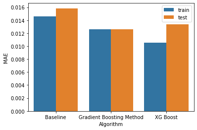

```python
plot_summary(baseline_train, baseline_pct,
             gbm_pct_train, gbm_pct,
             xgboost_pct_train, xgboost_pct)
```

**Figure 11. 3-Day Ahead Prediction Mean Absolute Errors**  
Varying mean absolute error scores between baseline (naive model) and employed regressor models

```python
table('Summary of Model Performance on 3-Day Ahead Prediction',
      'Values are in Percent Change')
display_table(results(baseline_pct, gbm_pct, xgboost_pct))

table('Summary of Model Performance on 3-Day Ahead Prediction',
      'Values are in PSEi')
display_table(results(baseline_psei, gbm_psei, xgboost_psei))
```

**Table 12. Summary of Model Performance on 3-Day Ahead Prediction.**  
Values are in Percent Change

|  | MAE | MSE |
| --- | --- | --- |
| Baseline | 0.015835 | 0.000415 |
| Gradient Boosting | 0.012591 | 0.000271 |
| XGB | 0.013397 | 0.000295 |

**Table 13. Summary of Model Performance on 3-Day Ahead Prediction.**  
Values are in PSEi

|  | MAE | MSE |
| --- | --- | --- |
| Baseline | 130.774638 | 28041.770412 |
| Gradient Boosting | 110.309334 | 19604.420569 |
| XGB | 115.560453 | 21077.380802 |

Consistently, since the first set of analysis until the end, both models have significantly beaten our baseline (naive model) metric values in terms of obtaining lower `MAE` and `MSE`. However, although the obtained `MAE` and `MSE` scores for both models are still lower than the baseline values, it is evident that the difference between the latter and the former is meager compared to the other sets of analysis. For 3-Day Ahead predictions, it is still the Gradient Boosting Regressor that provided the most desirable error scores compared to the XGB regressor. Conclusively, the Gradient Boosting Regressor model is still the one that used to identify the features that are relevant and important in predicting our target variable. The feature importance graph is presented below:

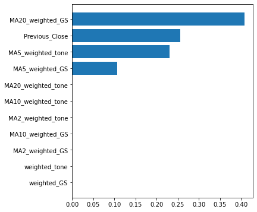

```python
feature_importance = model.feature_importances_
sorted_idx = np.argsort(feature_importance)
pos = np.arange(sorted_idx.shape[0]) + .5
fig = plt.figure(figsize=(12, 6))
plt.subplot(1, 2, 1)
plt.barh(pos, feature_importance[sorted_idx], align='center')
plt.yticks(pos, np.array(features_set)[sorted_idx])
#plt.title('Feature Importance')
plt.show();
```

**Figure 12. Model Feature Importances for 3-Day Ahead Prediction.**  
Ranked features based on importance in the prediction of the target variable.

Interestingly, the top 3 features for the 3-Day Prediction is sort of an amalgamation of the top features from the two preceding analyses with the emergence of a new feature. The three (3) that stood out are the following: '`MA20_weighted_GS`, `Previous_Close`, and `MA_5_weighted_tone`. Again, this tells us that in predicting the percent change in closing price three (3) days ahead, the sentiments from events twenty (20) days and five (5) days prior affect the prediction the most. Consistent with the day-ahead prediction, the previous closing price appeared to be significant in the predicting the traget variable. Similary, as observed with the day-ahead predictions, features after the 4th spot in the ranking appeared to be of little to no importance in the predictions.

6 CONCLUSION AND RECOMMENDATIONS

To further extend the study, we recommend the following:

1. Include the Philippines’ top trading partners such as member-countries of the Association of Southeast Asian Nations (ASEAN), USA, China, and Japan;
2. Convert to a classification problem wherein the model predicts whether the PSEi will go up or down;
3. Apply the model to specific stocks or other macroeconomic indicators, similar to [22] were they applied the same methodology in predicting GDP per capita and Business and Consumer Confidence indices; and
4. Consider use of deep learning models such as RNN, LSTM, and GRU.

7 REFERENCES

[1] French, Craig W. (2003). "The Treynor Capital Asset Pricing Model". Journal of Investment Management. 1 (2): 60–72. SSRN 447580

[2] Markowitz, H.M. (March 1952). "Portfolio Selection". The Journal of Finance. 7 (1): 77–91. doi:10.2307/2975974. JSTOR 2975974

[3] Ogunlusi, O. E., & Obademi, O. (2019). The Impact of Behavioural Finance on Investment Decision-making: A Study of Selected Investment Banks in Nigeria. Global Business Review. https://doi.org/10.1177/0972150919851388

[4] Moseki, K. K., & Madhava Rao, K. S. (2017). Analysing stock market data—Market sentiment approach and its measures. Cogent Economics & Finance, 5(1). doi:10.1080/23322039.2017.1367147

[5] Alamro, R., McCarren, A., & Al-Rasheed, A. (2019). Predicting Saudi Stock Market Index by Incorporating GDELT Using Multivariate Time Series Modelling. Advances in Data Science, Cyber Security and IT Applications, 317–328. doi:10.1007/978-3-030-36365-9_26

[6] Bloomberg. (n.d.). Philippine Stock Exchange PSEi Index. Accessed on January 18, 2021 from https://www.bloomberg.com/quote/PCOMP:IND

[7] The Philippine Stock Exchange, Inc. (n.d.). Indices Composition. Accessed on January 18, 2021 from https://pse.com.ph/stockMarket/marketInfo-marketActivity.html?tab=0

[8] Magturo, D.J. (2015). Aquino’s wish: PSEi at 10,000 by term’s end. Business World. Accessed on January 18, 2021 from https://www.bworldonline.com/content.php?section=TopStory&title=aquino&8217s-wish-psei-at-10000-by-term&8217s-end&id=106115

[9] Cabuenas, J.V.D. Stock market rides on bullish sentiment from the tax reform. Accessed on January 18, 2021 from https://www.gmanetwork.com/news/money/economy/637631/stock-market-rides-on-bullish-sentiment-from-the-tax-reform/story/

[10] Etac, N.A.M. and Ceballos, R.F. (2019). Forecasting the Volatilities of Philippine Stock Exchange Composite Index Using the Generalized Autoregressive Conditional Heteroskedasticity Modeling. International Journal of Statistics and Economics. 19(3). arXiv:1904.00749

[11] W S Gayo et al 2015 J. Phys.: Conf. Ser. 622 012022

[12] Registry of Open Data on AWS. Global Database of Events, Language and Tone (GDELT). Accessed on December 12, 2020 from https://registry.opendata.aws/gdelt/

[13] Yahoo! Finance. PSEi Index. Accessed on December 12, 2020 from https://finance.yahoo.com/quote/PSEI.PS/history?p=PSEI.PS

[14] R. Nabi, S. Ab. M. Saeed, and H. Harron, “A Novel Approach for Stock Price Prediction Using Gradient Boosting Machine with Feature Engineering (GBM-wFE)”, Kurdistan Journal of Applied Research, vol. 5, no. 1, pp. 28-48, Apr. 2020.

[15] Chen, Y., Jia, Z., Mercola, D., & Xie, X. (2013). A Gradient Boosting Algorithm for Survival Analysis via Direct Optimization of Concordance Index. Computational and Mathematical Methods in Medicine, 2013, 1–8. doi:10.1155/2013/873595

[16] Basak, S., Kar, S., Saha, S., Khaidem, L., & Dey, S. R. (2018). Predicting the direction of stock market prices using tree-based classifiers. The North American Journal of Economics and Finance. doi:10.1016/j.najef.2018.06.013

[17] Chen, L. (2020). Stock Price Prediction using Adaptive Time Series Forecasting and Machine Learning Algorithms. UCLA. ProQuest ID: Chen_ucla_0031N_18851. Merritt ID: ark:/13030/m5zs84k9. Retrieved from https://escholarship.org/uc/item/0zp9s76c

[18] X. Zhang and W. Chen, "Stock Selection Based on Extreme Gradient Boosting," 2019 Chinese Control Conference (CCC), Guangzhou, China, 2019, pp. 8926-8931, doi: 10.23919/ChiCC.2019.8865781.

[19]. Elshendy, M., & Fronzetti Colladon, A. (2017). Big data analysis of economic news: Hints to forecast macroeconomic indicators. International Journal of Engineering Business Management. https://doi.org/10.1177/1847979017720040

[20] Sci-kit Learn. (n.d.). sklearn.ensemble.GradientBoostingRegressor. Accessed on December 28, 2020 from https://scikit-learn.org/stable/modules/generated/sklearn.ensemble.GradientBoostingRegressor.html

[21] XGBoost. (n.d.). XGBoost Documentation. Accessed on December 29, 2020 from https://xgboost.readthedocs.io/en/latest/